# Plotting and Visualization

```python
## 모듈이란 함수나 변수 또는 클래스들을 모아 놓은 파일입니다. 밑 코드들은 모듈들을 불러오는 과정입니다.
## 파이썬으로 프로그래밍을 할 때 굉장히 많은 모듈을 사용하기 때문에 밑 코드들은 많이 보시게 될 것 입니다.
## import ex1 => ex1.py 모듈 파일을 불러오는 과정으로 ex1 안에 존재하는 함수를 사용할 수 있게 됩니다.
## from ex1 import sum => ex1.py 모듈파일에서 sum이라는 함수만 사용하는 방식입니다.
from numpy.random import randn ## numpy.random이라는 모듈 안의 randn 함수를 불러오는 코드.
import numpy as np ## numpy 모듈을 불러오며, numpy를 np로 대체
import matplotlib.pyplot as plt ## matplotlib.pyplot ## matplotlib.pylot 모듈을 불러오며 plt로 대체
from pandas import *
```

```python
##numpy.random 서브패키지는 numpy의 랜덤넘버 생성 관련 함수를 모아 놓은 것으로 다음과 같은 함수를 제공합니다.
## seed : pseudo random 상태 설정
## shuffle : 조합
## choice : 순열
## random_integers : uniform integer
## rand : uniform
## randn : Gaussina nomal
## 컴퓨터 프로그램에서 무작위와 관련된 알고리즘은 사실 무작위가 아니라 시작 숫자를 정해주면 그 다음에는 정해진 알고리즘에 의해 마치 난수 처럼
## 보이는 수열을 생성 하는 것입니다. 이와 같이 시작 숫자를 seed라 지칭합니다.
## seed는 0보다 크거나 같은 정수의 값을 가질 수 있습니다.간단히 seed의 역할을 밑에서 보여드리겠습니다.
```

```python
np.random.seed(0) ## 시드를 0으로 설정해준다.
a = np.random.rand(5) ## rand명령은 0과 1 사이의 난수를 발생시키는 명령어로 인수로 받은 숫자 횟수 만큼 난수를 발생시킵니다.
b = np.random.rand(10) ## 각각 난수를 a,b 변수에 저장합니다.
print(a)## a,b 출력과정
print(b)
```

```
[ 0.5488135   0.71518937  0.60276338  0.54488318  0.4236548 ]
[ 0.64589411  0.43758721  0.891773    0.96366276  0.38344152  0.79172504
  0.52889492  0.56804456  0.92559664  0.07103606]
```

```python
np.random.seed(0) ## 시디를 0으로 재설정해줍니다.
a = np.random.rand(5)
b = np.random.rand(10)
print(a)
print(b) ## 다시 난수를 발생시키는데 위와 동일한 값이 나오는 것을 확인 할 수 있습니다. seed 영향이죠.
```

```
[ 0.5488135   0.71518937  0.60276338  0.54488318  0.4236548 ]
[ 0.64589411  0.43758721  0.891773    0.96366276  0.38344152  0.79172504
  0.52889492  0.56804456  0.92559664  0.07103606]
```

```python
##np.random.seed(12345) ## seed를 12345로 설정
##plt.rc('figure', figsize=(10, 6))
```

```python
import pandas as pd ## pands 모듈을 불러오며 pd로 대체
np.set_printoptions(precision=4)
```

```python
%matplotlib inline
```

## 간단한 matplotlib API

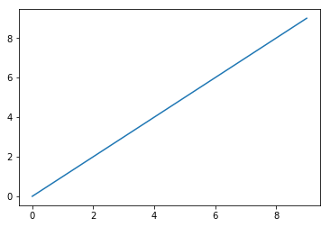

```python
plt.plot(np.arange(10)) ## matplotlib.plot(a) 형태입니다. 하나 값만 정해질 경우 a인수는 y값에 해당되며 x값은 자동적으로 y 갯수 만큼의 정수로
                        ## 정해집니다.
```

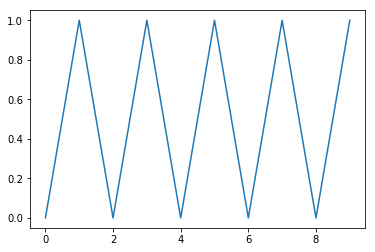

```python
plt.plot(np.arange(10),[0,1,0,1,0,1,0,1,0,1]) ## plot(a,b) a와 b값 모두 정해준 형태입니다. a는 x값이 되며 b는 y값이 된다.
```

### 실습예제 1

y=x인 그래프를 그리시오(범위 0~100)

## 수치 및 다중그림

```python
# 그래프는 Figure 객체내에 존재한다. 아래는 새로운 Figure 객체를 만든다
#fig = plt.figure()
```

```python
# 서브플롯을 만들어 그림을 추가한다
#ax1 = fig.add_subplot(2, 2, 1)
```

```python
#ax2 = fig.add_subplot(2, 2, 2)
#ax3 = fig.add_subplot(2, 2, 3)
```

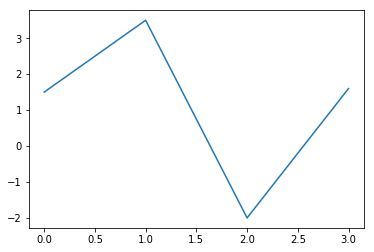

```python
plt.plot([1.5,3.5,-2,1.6]) ## plt.plot(a) 형식
```

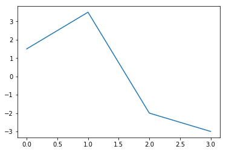

```python
plt.plot([1.5,3.5,-2,-3]) ## plt.plot(a) 형식
```

### 실습예제2

총 7번 꺾이는 꺾은선 그래프를 그리시오.

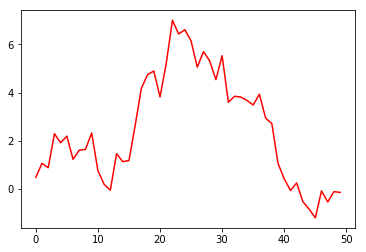

```python
plt.plot(randn(50).cumsum(), color = 'r') ##randn().cumsum()은 cumsum()함수는 누적합을 구하는 함수이다.
                                          ##plt.plot(a,color='?') 은 y값을 a로 받고, color를 배정하는 형식이다. 'r' = red , 'b' = blue 등이있다.
```

### 실습예제3

위의 그래프 그리는 방법을 응용하여 x축의 범위를 100으로 하는 그래프를 그리시오. 또 선의 색을 blue로 설정하시오.

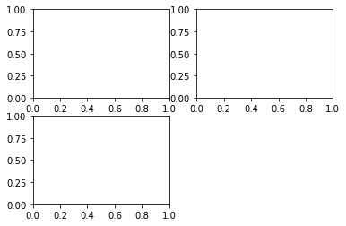

```python
fig = plt.figure() # 그래프는 Figure 객체내에 존재한다. 아래는 새로운 Figure 객체를 만든다
                   # 아래 출력 된 것이 Figure라 보면 됩니다.
ax1 = fig.add_subplot(2, 2, 1) ##fig.add_subplot(a,b,c) 는 Figure 객체내 서브plot를 넣는 것으로 a*b 행렬 에서 c는 위치를 나태낸다.
ax2 = fig.add_subplot(2, 2, 2) ## 2*2 행렬에서 2번째에 위치하는 plot
ax3 = fig.add_subplot(2, 2, 3)
```

```python
ax1.hist(randn(100), bins=20, color='k') ##  matplotlib.pyplot에는 여러가지 형태의 plot(그래프) 형식이 제공됩니다.
                                                    ##  hist : 히스토그램 . bar : 막대그래프 scatter : 산점도 pie: 원그래프 등등.
                                                    ##  ax1에 히스토그램 형식이며 bins 는 폭 설정 , color는 색깔 설정입니다.
ax2.scatter(np.arange(30), np.arange(30) + 3 * randn(30)) ## scatter 산점도
```

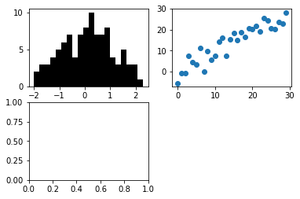

```python
fig
```

[output not shown]

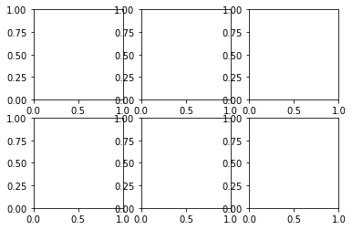

```python
axes = plt.subplots(2, 3) ## 2*3을 설정해주고 아래의 결과를 볼 수 있다.
axes
```

#### subplot 주변의 공간 고정

```python
plt.subplots_adjust(left=None, bottom=None, right=None, top=None,
                wspace=None, hspace=None) # subplot 간의 간격을 조정하는 함수 _adjust()
```

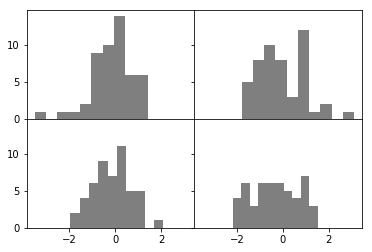

```python
fig, axes = plt.subplots(2, 2, sharex=True, sharey=True) #각 subplot이 sharex=true x축 공유  sharey=y축을 공유한다.
for i in range(2):
    for j in range(2): # for 구문은 for i in range() 범위 만큼 i를 반복 한다는 구문이다.
        axes[i, j].hist(randn(50), bins=10, color='k', alpha=0.5) ## 이중 for 구문으로 [0,0] , [0,1] , [1,0] , [1,1] 순으로 반복.
plt.subplots_adjust(wspace=0, hspace=0) # 인수 값들을 변경해서 어떤 인수들이 어떤 작용을 하는지 볼 수 있다!
```

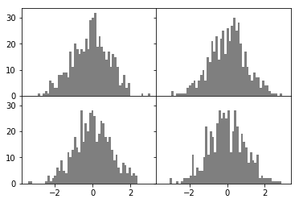

```python
fig, axes = plt.subplots(2, 2, sharex=True, sharey=True)
for i in range(2):
    for j in range(2):
        axes[i, j].hist(randn(500), bins=50, color='k', alpha=0.5)
plt.subplots_adjust(wspace=0, hspace=0)
```

### 실습예제 4

위의 코드를 참고하여 9개의 랜덤한 히스토그램을 그리시오.

### 색, 점 모양, 선 스타일

```python
plt.figure()
```

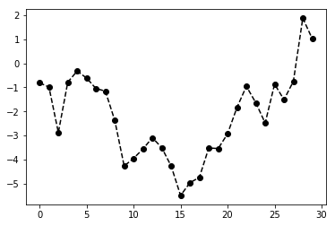

```python
plt.plot(randn(30).cumsum(), 'ko--') #cumsum()함수는 행렬의 누적 합을 구함 ex) 행렬이 1 2 3
                                     #                                                4 5 6 일 경우
                                     #cumsum() 후의 값은 1 3 6 10 15 21 이 됨.
                                     #'ko--'는 k색깔의 선의 형태를 o--를 뜻하며 'ko'로 인수를 바꾸어 결과의 변화를 확인해보자
```

### 실습예제5

꺾이는 부분에 사각형으로 점을 찍고 점선이며 파란 색인 그래프를 그리시오.

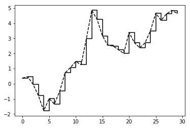

```python
data = randn(30).cumsum()
plt.plot(data, 'k--', label='Default')
plt.plot(data, 'k-', drawstyle='steps-post', label='steps-post') # drawstyle='steps-post' 계단식 표현 뜻한다
```

### 그래프 세부내용(범례, 축 이름 등)

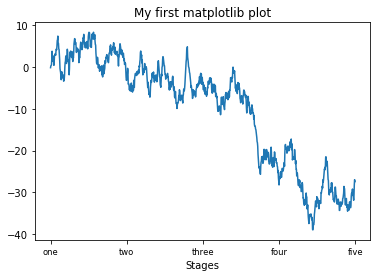

```python
fig = plt.figure(); ax = fig.add_subplot(1, 1, 1)
ax.plot(randn(1000).cumsum())

ticks = ax.set_xticks([0, 250, 500, 750, 1000])
labels = ax.set_xticklabels(['one', 'two', 'three', 'four', 'five'],
                            fontsize='small')
ax.set_title('My first matplotlib plot') ## title 설정
ax.set_xlabel('Stages') ## x축 label 설정
```

### 실습예제6

위의 예제 그래프를 그대로 그리되 그래프의 제목, x축 이름을 한글로 바꾸고 y축의 이름을 추가하시오.

#### 범주 추가

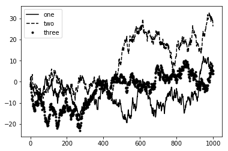

```python
fig = plt.figure(); ax = fig.add_subplot(1, 1, 1)
ax.plot(randn(1000).cumsum(), 'k', label='one')
ax.plot(randn(1000).cumsum(), 'k--', label='two')
ax.plot(randn(1000).cumsum(), 'k.', label='three')

ax.legend(loc='best') #최적의 장소에 범례를 위치 (loc = location)
```

### 실습예제7

위의 그래프의 범례를 오른쪽 아래 위치로 이동시키십시오.(힌트 : location 위치에 아무 글씨나 집어넣으면 힌트가 나옵니다.)

### subplot 주석달기 및 그리는 방법

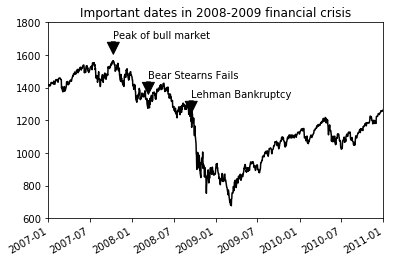

```python
from datetime import datetime

fig = plt.figure()
ax = fig.add_subplot(1, 1, 1)

data = pd.read_csv('data/spx.csv', index_col=0, parse_dates=True)
spx = data['SPX']

spx.plot(ax=ax, style='k-')

crisis_data = [
    (datetime(2007, 10, 11), 'Peak of bull market'),
    (datetime(2008, 3, 12), 'Bear Stearns Fails'),
    (datetime(2008, 9, 15), 'Lehman Bankruptcy')
]

for date, label in crisis_data:
    ax.annotate(label, xy=(date, spx.asof(date) + 50), #asof함수를 사용, x,y 좌표를 해당 날짜의 가장 근접한 위치로 함, +는 위치설정
                xytext=(date, spx.asof(date) + 200),
                arrowprops=dict(facecolor='black'), #화살표
                horizontalalignment='left', verticalalignment='top')#주석달기

ax.set_xlim(['1/1/2007', '1/1/2011'])
ax.set_ylim([600, 1800])

ax.set_title('Important dates in 2008-2009 financial crisis')
```

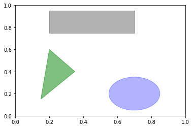

```python
fig = plt.figure()
ax = fig.add_subplot(1, 1, 1)

rect = plt.Rectangle((0.2, 0.75), 0.5, 0.2, color='k', alpha=0.3) ##(0.2,0.75) 사각형의 시작점 0.5 가로길이 0.2 세로길이를 뜻한다.
                                                            ## alpha 색깔의 명도를 나타내준다 인수를 바꿔서 결과 변화를 확인해보자!
circ = plt.Circle((0.7, 0.2), 0.15, color='b', alpha=0.3) ## (0,7,0,2) 원의 중심 을 뜻한다 / 0.15 원의 반지름을 뜻한다.
pgon = plt.Polygon([[0.15, 0.15], [0.35, 0.4], [0.2, 0.6]], #꼭지점의 좌표
                   color='g', alpha=0.5)

ax.add_patch(rect) ## ax subplot에 도형을 추가한다.
ax.add_patch(circ)
ax.add_patch(pgon)
```

### 실습예제8

위의 그래프를 응용해 오각형 도형을 그리시오.

### 그림(그래프)를 파일로 저장하기

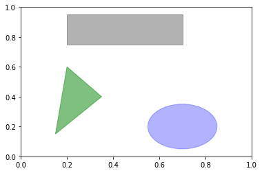

```python
fig
```

```python
fig.savefig('figpath.svg')
```

```python
fig.savefig('figpath.png', dpi=400, bbox_inches='tight') #save figure (.savefig())
```

```python
from io import BytesIO
buffer = BytesIO()
plt.savefig(buffer)
plot_data = buffer.getvalue()
```

## pandas에서의 제도 방법

### 선 그래프

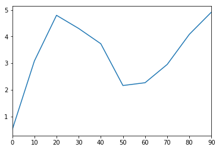

```python
s = Series(np.random.randn(10).cumsum(), index=np.arange(0, 100, 10))
s.plot()
```

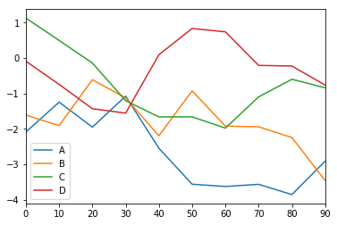

```python
df = DataFrame(np.random.randn(10, 4).cumsum(0),
               columns=['A', 'B', 'C', 'D'],
               index=np.arange(0, 100, 10))
df.plot()
```

### 실습예제9

위 그래프의 라인을 7개로 늘리십시오.

### 막대 그래프

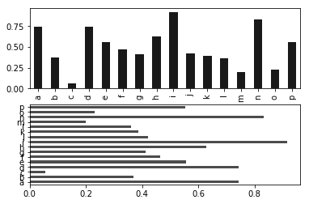

```python
fig, axes = plt.subplots(2, 1)
data = Series(np.random.rand(16), index=list('abcdefghijklmnop')) #x축의 이름을 list로 문자열형태로 지정
data.plot(kind='bar', ax=axes[0], color='k', alpha=0.9)
data.plot(kind='barh', ax=axes[1], color='k', alpha=0.7)
```

### 실습예제10

상단의 1번 그래프의 x축과 2번그래프의 y축을 0부터 9까지의 10개의 숫자로 바꾸고 그래프의 색을 노란색으로 바꿔 그리십시오.

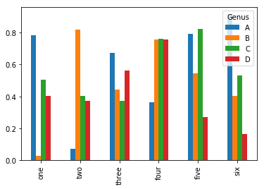

```python
df = DataFrame(np.random.rand(6, 4),
               index=['one', 'two', 'three', 'four', 'five', 'six'],
               columns=pd.Index(['A', 'B', 'C', 'D'], name='Genus'))
df
df.plot(kind='bar')
```

```python
plt.figure()
```

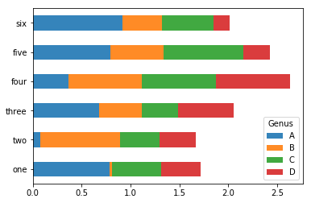

```python
df.plot(kind='barh', stacked=True, alpha=0.9)
```

```python
tips = pd.read_csv('data/tips.csv')
party_counts = pd.crosstab(tips['day'], tips['size'])
print(party_counts)
# 2~5명의 파티 데이터만 추출
ptt=party_counts.ix[:, 2:5]
print(ptt)
```

```
size  1   2   3   4  5  6
day
Fri   1  16   1   1  0  0
Sat   2  53  18  13  1  0
Sun   0  39  15  18  3  1
Thur  1  48   4   5  1  3
size   2   3   4  5
day
Fri   16   1   1  0
Sat   53  18  13  1
Sun   39  15  18  3
Thur  48   4   5  1
```

```python
tips.head(10)
```

|  | total_bill | tip | sex | smoker | day | time | size |
| --- | --- | --- | --- | --- | --- | --- | --- |
| 0 | 16.99 | 1.01 | Female | No | Sun | Dinner | 2 |
| 1 | 10.34 | 1.66 | Male | No | Sun | Dinner | 3 |
| 2 | 21.01 | 3.50 | Male | No | Sun | Dinner | 3 |
| 3 | 23.68 | 3.31 | Male | No | Sun | Dinner | 2 |
| 4 | 24.59 | 3.61 | Female | No | Sun | Dinner | 4 |
| 5 | 25.29 | 4.71 | Male | No | Sun | Dinner | 4 |
| 6 | 8.77 | 2.00 | Male | No | Sun | Dinner | 2 |
| 7 | 26.88 | 3.12 | Male | No | Sun | Dinner | 4 |
| 8 | 15.04 | 1.96 | Male | No | Sun | Dinner | 2 |
| 9 | 14.78 | 3.23 | Male | No | Sun | Dinner | 2 |

```
size         2         3         4         5
day
Fri   0.888889  0.055556  0.055556  0.000000
Sat   0.623529  0.211765  0.152941  0.011765
Sun   0.520000  0.200000  0.240000  0.040000
Thur  0.827586  0.068966  0.086207  0.017241
```

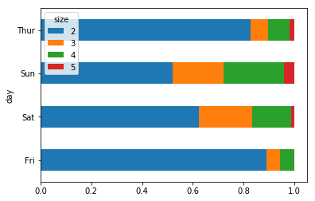

```python
party_pcts = ptt.div(ptt.sum(1).astype(float), axis=0)
print(party_pcts)

party_pcts.plot(kind='barh', stacked=True)
```

### 실습예제11

위 그래프를 가로축 중심의 그래프로 그리시오.

### 히스토그램 및 밀도 그래프

```python
plt.figure()
```

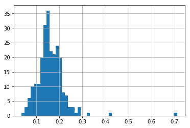

```python
tips['tip_pct'] = tips['tip'] / tips['total_bill']
tips['tip_pct'].hist(bins=50) # bins는 막대의 범위(굵기)이다.
```

```python
plt.figure()
```

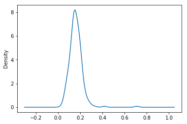

```python
# 커널 밀도 추정 그래프 Kernel Sensity Estimate
tips['tip_pct'].plot(kind='kde')
```

```python
plt.figure()
```

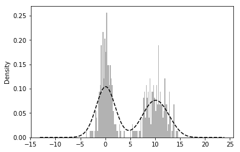

```python
comp1 = np.random.normal(0, 1, size=200)  # N(0, 1)
comp2 = np.random.normal(10, 2, size=200)  # N(10, 4)
values = Series(np.concatenate([comp1, comp2])) #concat(1,2) -1번째 문자열에 두번째 문자열을 합치는 함수와 동일
values.hist(bins=100, alpha=0.3, color='k', normed=True)
values.plot(kind='kde', style='k--')
```

### 실습예제12

위의 그래프의 막대 부분의 색을 진하게 하고 점선으로 된 커널 밀도 추정 그래프를 실선으로 표시하시오.

### 산점도 그래프

```python
macro = pd.read_csv('data/macrodata.csv')
data = macro[['cpi', 'm1', 'tbilrate', 'unemp']]
trans_data = np.log(data).diff().dropna() #dropna는 nan 즉 0의 값을 뺀다는 의미. diff()는 미분하는 함수, log()는 log함수를 취하는 함수.
trans_data[-5:]
```

|  | cpi | m1 | tbilrate | unemp |
| --- | --- | --- | --- | --- |
| 198 | -0.007904 | 0.045361 | -0.396881 | 0.105361 |
| 199 | -0.021979 | 0.066753 | -2.277267 | 0.139762 |
| 200 | 0.002340 | 0.010286 | 0.606136 | 0.160343 |
| 201 | 0.008419 | 0.037461 | -0.200671 | 0.127339 |
| 202 | 0.008894 | 0.012202 | -0.405465 | 0.042560 |

```python
plt.figure()
```

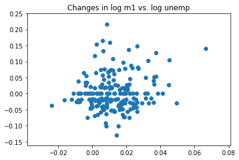

```python
plt.scatter(trans_data['m1'], trans_data['unemp'])
plt.title('Changes in log %s vs. log %s' % ('m1', 'unemp'))
```

### 실습예제13

위의 Scatter plot의 x축을 trans_data의 cpi, y축을 tbilrate로 한 scatter plot을 그리고 제목을 그에 맞게 바꾸시오.

[output not shown]

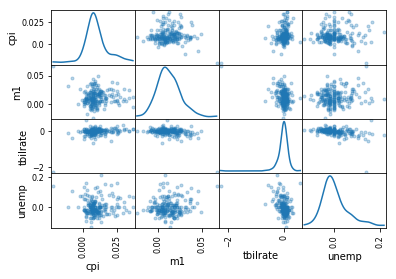

```python
pd.scatter_matrix(trans_data, diagonal='kde', alpha=0.3) #모든 x축과 y축을 사용해 행렬의 형태로 나타내는 scatter_matrix
```

### 실습예제14

위의 산점도 매트릭스의 산점도의 점 색을 붉은 색으로 하고 모양을 네모로 바꾸시오(marker 이용)